# Kononova

Имеются данные: Набор данных `Bank` содержит сведения о результатах прямых маркетинговых кампаний (прямые обзвоны), проводимых португальскими банками в 2008 – 2010 гг. Цель – предсказать, сделает ли клиент срочный вклад (переменная `y`). Список столбцов (данные о потенциальных клиентах, которым звонили):

*Данные банковского досье*

*Данные банковского обзвона*

1. **`contact`** – тип обзвона: `telephone` – по стационарному телефону, `cellular` – по сотовому.
2. **`month`** – месяц последнего звонка.
3. **`day_of_week`** – день недели последнего звонка.
4. **`duration`** – длительность посленднего звонка. Внимание: до начала разговора значение неизвестно, а после окончания разговора ещё не известен результат (купит ли продукт банка).
5. **`campaign`** – количество контактов с этим клиентом за посленднюю компанию, включая последний звонок.
6. **`pdays`** – сколько прошло дней с последнего звонка клиенту в предыдущую маркетинговую кампанию (значение 999 означает, что звоним впервые).
7. **`previous`** – сколько раз звонили клиенту в последнюю маркетинговую кампанию.
8. **`poutcome`** – чем кончился контакт с клиентом в предыдущую кампанию: `failure` – неудача, `nonexistent` – контакта не было, `success` – успех.

*Целевая переменная*

1. **`y`** – открыл ли клиент срочный вклад: `yes` – да, `no` – нет.

Нужно узнать зависит ли открытие клиентом срочного вкалада от возраста, места работы, семейного положения, образования клиента, наличия у него кредита и дефолта по нему, ипотеки; и зависит ли открытие вклада от данных банковского обзвона, таких как дата обзвона, количество контактов, тип обзвона, количество звонков, успешное окончание контакта.

```r
library('ISLR')
library('MASS')
library('boot')
library('e1071')     # SVM
library('tree')
library('randomForest')      # случайный лес randomForest()
library('gbm')               # бустинг gbm()

#Загружаем данные
data <- read.csv("Bank_for_models.csv", header = TRUE, dec = ",", sep = ";")
head(data)
```

|  | age | job | marital | education | default | balance | housing | loan | contact | day | month | duration | campaign | pdays | previous | poutcome | y |
| --- | --- | --- | --- | --- | --- | --- | --- | --- | --- | --- | --- | --- | --- | --- | --- | --- | --- |
| 1 | 37 | blue-collar | single | secondary | no | 3572 | yes | yes | cellular | 20 | nov | 341 | 2 | -1 | 0 | unknown | no |
| 2 | 33 | blue-collar | married | secondary | no | 2254 | yes | no | cellular | 17 | apr | 130 | 1 | 148 | 1 | failure | no |
| 3 | 42 | blue-collar | married | secondary | no | 634 | yes | no | cellular | 24 | jul | 256 | 2 | -1 | 0 | unknown | no |
| 4 | 57 | technician | married | secondary | no | 104 | no | no | cellular | 27 | aug | 86 | 5 | -1 | 0 | unknown | no |
| 5 | 32 | technician | single | secondary | no | 4069 | yes | no | cellular | 25 | jul | 273 | 1 | -1 | 0 | unknown | no |
| 6 | 50 | unemployed | divorced | secondary | no | 32 | no | no | cellular | 4 | aug | 282 | 2 | -1 | 0 | unknown | no |

```r
df.train <- data
my.seed <- 11

#Представляем переменные как факторы
df.train$job <- as.factor(df.train$job)
df.train$marital <- as.factor(df.train$marital)
df.train$education <- as.factor(df.train$education)
df.train$default <- as.factor(df.train$default)
df.train$housing <- as.factor(df.train$housing)
df.train$loan <- as.factor(df.train$loan)
df.train$contact <- as.factor(df.train$contact)
df.train$month <- as.factor(df.train$month)
df.train$poutcome <- as.factor(df.train$poutcome)
df.train$y <- as.factor(df.train$y)
```

*Построим модель с помощью деревьев классификации*

```r
tree.y <- tree(y ~ ., df.train)

summary(tree.y)
```

```
##
## Classification tree:
## tree(formula = y ~ ., data = df.train)
## Variables actually used in tree construction:
## [1] "duration" "poutcome" "month"    "contact"
## Number of terminal nodes:  9
## Residual mean deviance:  0.4895 = 19910 / 40680
## Misclassification error rate: 0.1103 = 4487 / 40689
```

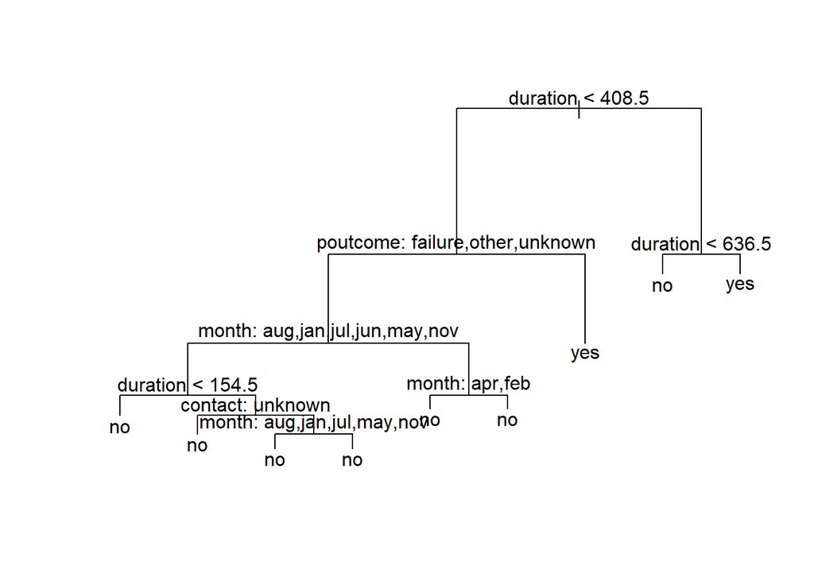

```r
# график результата

plot(tree.y)              # ветви

text(tree.y, pretty = 0)  # подписи
```

```r
tree.y                    # посмотреть всё дерево в консоли
```

```
## node), split, n, deviance, yval, (yprob)
##       * denotes terminal node
##
##  1) root 40689 29440.0 no ( 0.882548 0.117452 )
##    2) duration < 408.5 33847 16750.0 no ( 0.932372 0.067628 )
##      4) poutcome: failure,other,unknown 32786 13060.0 no ( 0.949796 0.050204 )
##        8) month: aug,jan,jul,jun,may,nov 27665  7041.0 no ( 0.972131 0.027869 )
##         16) duration < 154.5 14519  1254.0 no ( 0.992699 0.007301 ) *
##         17) duration > 154.5 13146  5265.0 no ( 0.949414 0.050586 )
##           34) contact: unknown 4788   236.9 no ( 0.996241 0.003759 ) *
##           35) contact: cellular,telephone 8358  4553.0 no ( 0.922589 0.077411 )
##             70) month: aug,jan,jul,may,nov 8070  3782.0 no ( 0.937299 0.062701 ) *
##             71) month: jun 288   399.1 no ( 0.510417 0.489583 ) *
##        9) month: apr,dec,feb,mar,oct,sep 5121  4683.0 no ( 0.829135 0.170865 )
##         18) month: apr,feb 3911  2772.0 no ( 0.886218 0.113782 ) *
##         19) month: dec,mar,oct,sep 1210  1575.0 no ( 0.644628 0.355372 ) *
##      5) poutcome: success 1061  1423.0 yes ( 0.393968 0.606032 ) *
##    3) duration > 408.5 6842  8972.0 no ( 0.636071 0.363929 )
##      6) duration < 636.5 3841  4310.0 no ( 0.751106 0.248894 ) *
##      7) duration > 636.5 3001  4159.0 yes ( 0.488837 0.511163 ) *
```

```r
# Оцениваем точность ===========================================================


# ядро генератора случайных чисел

set.seed(my.seed)


# обучающая выборка

train <- sample(1:nrow(df.train), 200)


# тестовая выборка

Y.test <- df.train[-train,]
test.tree.y <- df.train$y[-train]


# строим дерево на обучающей выборке

tree.y <- tree(y ~ . , df.train, subset = train)


# Оцениваем точность ###########################################################



# делаем прогноз

tree.pred <- predict(tree.y, Y.test, type = "class")


# матрица неточностей

tbl <- table(tree.pred, test.tree.y)


# ACC на тестовой

acc.test <- sum(diag(tbl))/sum(tbl)

names(acc.test)[length(acc.test)] <- 'Bank.class.tree.all'

acc.test
```

```
## Bank.class.tree.all
##           0.8329423
```

Попробуем обрезать дерево для улучшения результатов

```r
# Готовимся к обрезке дерева ===================================================

set.seed(my.seed)

cv.y <- cv.tree(tree.y, FUN = prune.misclass)

# имена элементов полученного объекта

names(cv.y)
```

```
## [1] "size"   "dev"    "k"      "method"
```

```r
# сам объект

cv.y
```

```
## $size
## [1] 12  8  6  5  1
##
## $dev
## [1] 38 38 36 35 33
##
## $k
## [1] -Inf 0.00 1.50 2.00 2.25
##
## $method
## [1] "misclass"
##
## attr(,"class")
## [1] "prune"         "tree.sequence"
```

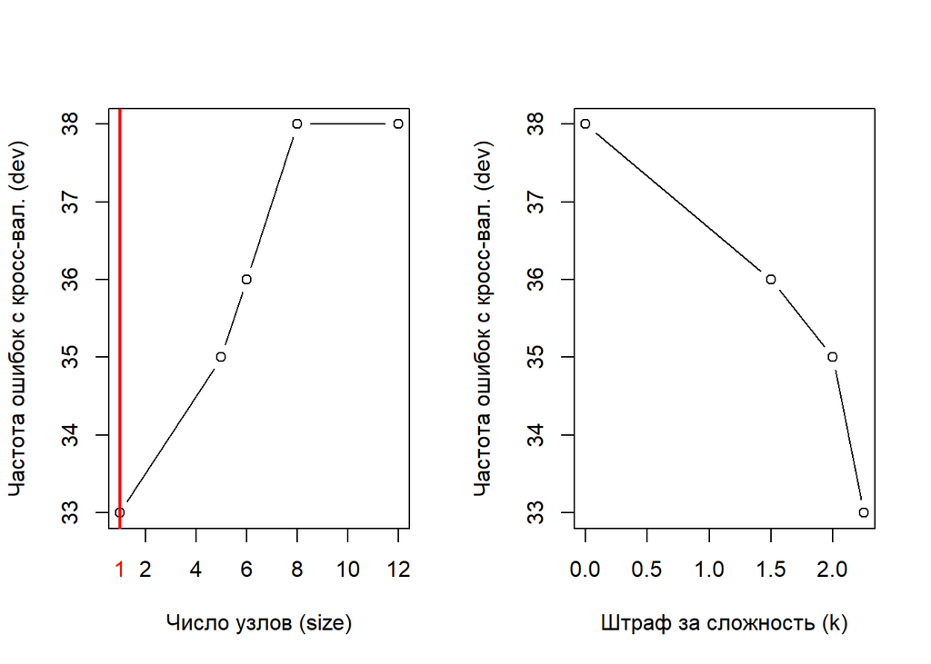

```r
# графики изменения параметров метода по ходу обрезки дерева ###################


# 1. ошибка с кросс-валидацией в зависимости от числа узлов

par(mfrow = c(1, 2))

plot(cv.y$size, cv.y$dev, type = "b",

     ylab = 'Частота ошибок с кросс-вал. (dev)',

     xlab = 'Число узлов (size)')

# размер дерева с минимальной ошибкой

opt.size <- cv.y$size[cv.y$dev == min(cv.y$dev)]

abline(v = opt.size, col = 'red', 'lwd' = 2)     # соотв. вертикальная прямая

mtext(opt.size, at = opt.size, side = 1, col = 'red', line = 1)


# 2. ошибка с кросс-валидацией в зависимости от штрафа на сложность

plot(cv.y$k, cv.y$dev, type = "b",

     ylab = 'Частота ошибок с кросс-вал. (dev)',

     xlab = 'Штраф за сложность (k)')
```

```r
# Обрезаем: дерево с 4 узлами ##################################################

prune.y <- prune.misclass(tree.y, best = 4)

# визуализация

plot(prune.y)

text(prune.y, pretty = 0)

# Оцениваем точность ###########################################################


# прогноз на тестовую выборку

tree.pred <- predict(prune.y, Y.test, type = "class")


# матрица неточностей

tbl <- table(tree.pred, test.tree.y)


# ACC на тестовой

acc.test <- c(acc.test, sum(diag(tbl))/sum(tbl))

names(acc.test)[length(acc.test)] <- 'Bank.class.tree.4'

acc.test
```

```
## Bank.class.tree.all   Bank.class.tree.4
##           0.8329423           0.8544296
```

[figure not shown]

```r
# сбрасываем графические параметры

par(mfrow = c(1, 1))
```

Обратимся к другим методам.

*Бэггинг*

```r
# Бэггинг ----------------------------------------------------------------------


# Обучаем модель ###############################################################

# бэггинг с 16 предикторами

set.seed(my.seed)

bag.bank <- randomForest(y ~ ., data = df.train, subset = train,

                           mtry = 16, importance = TRUE)

bag.bank
```

```
##
## Call:
##  randomForest(formula = y ~ ., data = df.train, mtry = 16, importance = TRUE,      subset = train)
##                Type of random forest: classification
##                      Number of trees: 500
## No. of variables tried at each split: 16
##
##         OOB estimate of  error rate: 16.5%
## Confusion matrix:
##      no yes class.error
## no  160  14  0.08045977
## yes  19   7  0.73076923
```

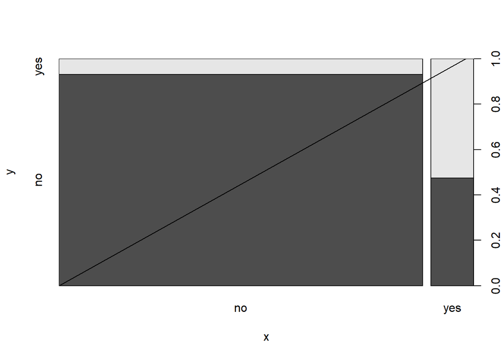

```r
# Оцениваем точность ###########################################################


# прогноз

yhat.bag <- predict(bag.bank, newdata = df.train[-train, ])


# график "прогноз -- реализация"

plot(yhat.bag, test.tree.y)

# линия идеального прогноза

abline(0, 1)
```

```r
# матрица неточностей

tbl <- table(yhat.bag, test.tree.y)



# ACC на тестовой

acc.test <- c(acc.test, sum(diag(tbl))/sum(tbl))

names(acc.test)[length(acc.test)] <- 'Bank.bag.16'

acc.test
```

```
## Bank.class.tree.all   Bank.class.tree.4         Bank.bag.16
##           0.8329423           0.8544296           0.8878955
```

Попробуем бэггинг с 25 деревьями

```r
# Обучаем модель ###############################################################


# бэггинг с 16 предикторами и 25 деревьями

bag.bank <- randomForest(y ~ ., data = df.train, subset = train,

                           mtry = 16, ntree = 25)



# прогноз

yhat.bag <- predict(bag.bank, newdata = df.train[-train, ])

# Оцениваем точность ###########################################################
# матрица неточностей

tbl <- table(yhat.bag, test.tree.y)



# ACC на тестовой

acc.test <- c(acc.test, sum(diag(tbl))/sum(tbl))

names(acc.test)[length(acc.test)] <- 'Bank.bag.16.25'

acc.test
```

```
## Bank.class.tree.all   Bank.class.tree.4         Bank.bag.16
##           0.8329423           0.8544296           0.8878955
##      Bank.bag.16.25
##           0.8895502
```

Теперь обратимся к методу случайного леса

```r
# Случайный лес ----------------------------------------------------------------



# Обучаем модель ###############################################################

set.seed(my.seed)

rf.bank <- randomForest(y ~ ., data = df.train, subset = train,

                          mtry = 6, importance = TRUE)


# Оцениваем точность ###########################################################

# прогноз

yhat.rf <- predict(rf.bank, newdata = df.train[-train, ])



# Оцениваем точность ###########################################################
# матрица неточностей

tbl <- table(yhat.rf, test.tree.y)



# ACC на тестовой

acc.test <- c(acc.test, sum(diag(tbl))/sum(tbl))

names(acc.test)[length(acc.test)] <- 'Bank.rf.6'

acc.test
```

```
## Bank.class.tree.all   Bank.class.tree.4         Bank.bag.16
##           0.8329423           0.8544296           0.8878955
##      Bank.bag.16.25           Bank.rf.6
##           0.8895502           0.8934525
```

```r
# важность предикторов

importance(rf.bank)  # оценки
```

```
##                   no         yes MeanDecreaseAccuracy MeanDecreaseGini
## age        2.4183814  1.72126461           2.92025723      3.896141141
## job       -1.4772881 -2.53004321          -2.50854014      3.666219920
## marital   -0.5665454  2.68589264           0.84227284      1.160487879
## education -0.4182439  0.96971018          -0.01980072      1.467956821
## default    0.0000000  0.00000000           0.00000000      0.009155556
## balance    0.3280177  1.83102844           1.12558841      2.961867135
## housing    1.4395095  3.66325940           3.02451972      0.965169971
## loan      -1.5992191 -2.61590762          -2.42163185      0.261138828
## contact    4.1076568 -0.01939836           3.64466363      1.159483509
## day        3.0976147 -0.21134643           2.78133196      3.194411505
## month      5.9818680  3.91282764           7.23651590      6.796527757
## duration  11.7639687 17.38082460          17.35337570     11.778248876
## campaign   0.6274155 -1.55171951          -0.15469005      1.238553955
## pdays      4.9496188 -0.33143865           4.68091740      1.231987907
## previous   3.2625569  0.50735727           3.07116333      1.611393118
## poutcome  11.0532542 12.82465194          14.39132997      3.940498980
```

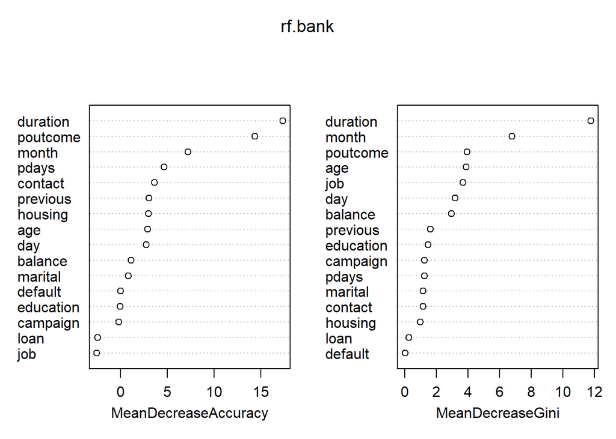

```r
varImpPlot(rf.bank)  # графики
```

Так же попробуем построить модель с помощью бустинга

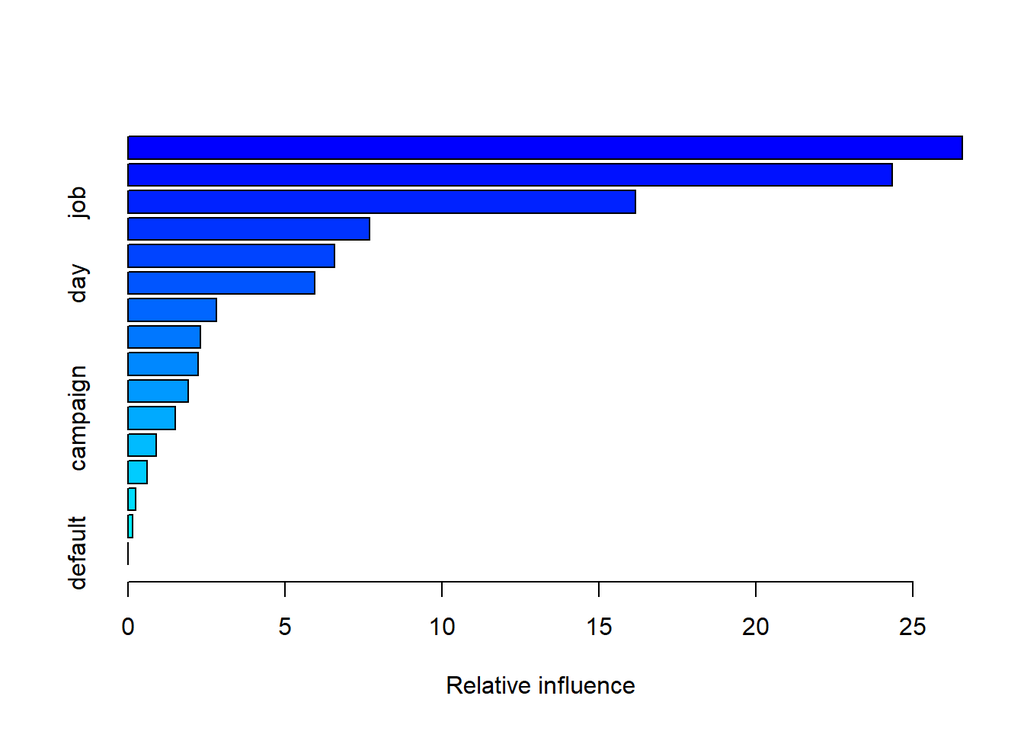

|  | var | rel.inf |
| --- | --- | --- |
| month | month | 26.5701735 |
| duration | duration | 24.3522291 |
| job | job | 16.1631999 |
| age | age | 7.6977507 |
| balance | balance | 6.5838655 |
| day | day | 5.9397210 |
| education | education | 2.8211146 |
| marital | marital | 2.2974309 |
| housing | housing | 2.2351400 |
| pdays | pdays | 1.9245148 |

[output cut: 6 more lines]

```r
# Бустинг ----------------------------------------------------------------------


# Обучаем модель ###############################################################


set.seed(my.seed)

boost.bank <- gbm(y ~ ., data = df.train[train, ], distribution = "gaussian",

                    n.trees = 5000, interaction.depth = 4)

# график и таблица относительной важности переменных

summary(boost.bank)
```

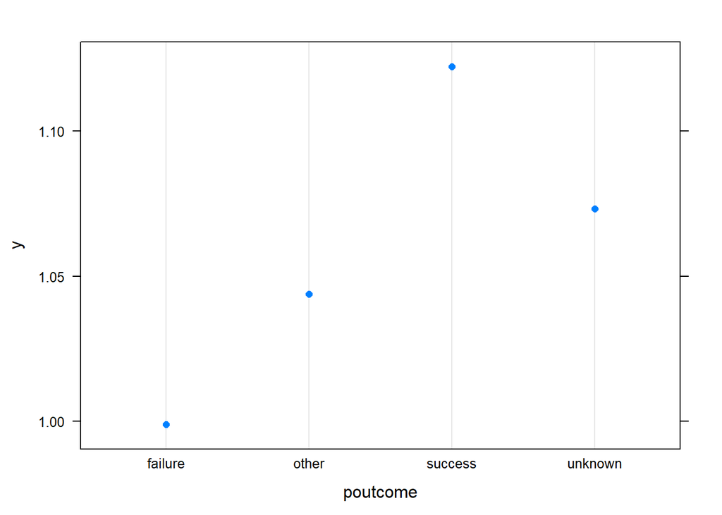

```r
# графики частной зависимости для двух наиболее важных предикторов

par(mfrow = c(1, 2))

plot(boost.bank, i = "poutcome")
```

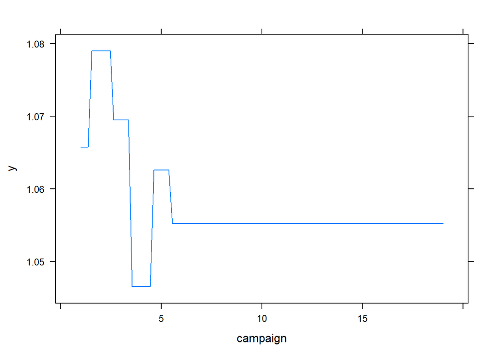

```r
plot(boost.bank, i = "campaign")
```

```r
# Оцениваем точность ###########################################################


# прогноз

yhat.boost <- predict(boost.bank, newdata = df.train[-train, ], n.trees = 5000)

# матрица неточностей

tbl <- table(yhat.boost, test.tree.y)



# ACC на тестовой

acc.test <- c(acc.test, sum(diag(tbl))/sum(tbl))

names(acc.test)[length(acc.test)] <- 'Bank.boost'

acc.test
```

```
## Bank.class.tree.all   Bank.class.tree.4         Bank.bag.16
##        8.329423e-01        8.544296e-01        8.878955e-01
##      Bank.bag.16.25           Bank.rf.6          Bank.boost
##        8.895502e-01        8.934525e-01        2.469807e-05
```

И посмотрим как поменяются результаты при значении гиперпараметра (lambda) 0.2

```r
# меняем значение гиперпараметра (lambda) на 0.2 -- аргумент shrinkage

boost.boston <- gbm(y ~ ., data = df.train[train, ], distribution = "gaussian",

                    n.trees = 5000, interaction.depth = 4,

                    shrinkage = 0.2, verbose = F)


# Оцениваем точность ###########################################################



# прогноз

yhat.boost <- predict(boost.bank, newdata = df.train[-train, ], n.trees = 5000)

# матрица неточностей

tbl <- table(yhat.boost, test.tree.y)



# ACC на тестовой

acc.test <- c(acc.test, sum(diag(tbl))/sum(tbl))

names(acc.test)[length(acc.test)] <- 'Bank.boost.0.2'

acc.test
```

```
## Bank.class.tree.all   Bank.class.tree.4         Bank.bag.16
##        8.329423e-01        8.544296e-01        8.878955e-01
##      Bank.bag.16.25           Bank.rf.6          Bank.boost
##        8.895502e-01        8.934525e-01        2.469807e-05
##      Bank.boost.0.2
##        2.469807e-05
```

Теперь попробуем использовать машины опорныз векторов

```r
###### Машины опорных векторов

# SVM с радиальным ядром и маленьким cost

svmfit <- svm(y ~ ., data = df.train[train, ], kernel = "radial",

              gamma = 1, cost = 1)


summary(svmfit)
```

```
##
## Call:
## svm(formula = y ~ ., data = df.train[train, ], kernel = "radial",
##     gamma = 1, cost = 1)
##
##
## Parameters:
##    SVM-Type:  C-classification
##  SVM-Kernel:  radial
##        cost:  1
##       gamma:  1
##
## Number of Support Vectors:  200
##
##  ( 174 26 )
##
##
## Number of Classes:  2
##
## Levels:
##  no yes
```

```r
# SVM с радиальным ядром и большим cost

svmfit <- svm(y ~ ., data = df.train[train, ], kernel = "radial",

              gamma = 1, cost = 1e5)

summary(svmfit)
```

```
##
## Call:
## svm(formula = y ~ ., data = df.train[train, ], kernel = "radial",
##     gamma = 1, cost = 1e+05)
##
##
## Parameters:
##    SVM-Type:  C-classification
##  SVM-Kernel:  radial
##        cost:  1e+05
##       gamma:  1
##
## Number of Support Vectors:  200
##
##  ( 174 26 )
##
##
## Number of Classes:  2
##
## Levels:
##  no yes
```

```r
# перекрёстная проверка

set.seed(my.seed)

tune.out <- tune(svm, y ~ ., data = df.train[train, ], kernel = "radial",

                 ranges = list(cost = c(0.1, 1, 10, 100, 1000),

                               gamma = c(0.5, 1, 2, 3, 4)))

summary(tune.out)
```

```
##
## Parameter tuning of 'svm':
##
## - sampling method: 10-fold cross validation
##
## - best parameters:
##  cost gamma
##   0.1   0.5
##
## - best performance: 0.13
##
## - Detailed performance results:
##     cost gamma error dispersion
## 1  1e-01   0.5  0.13 0.08563488
## 2  1e+00   0.5  0.13 0.08563488
## 3  1e+01   0.5  0.13 0.08563488
## 4  1e+02   0.5  0.13 0.08563488
## 5  1e+03   0.5  0.13 0.08563488
## 6  1e-01   1.0  0.13 0.08563488
## 7  1e+00   1.0  0.13 0.08563488
## 8  1e+01   1.0  0.13 0.08563488
## 9  1e+02   1.0  0.13 0.08563488
## 10 1e+03   1.0  0.13 0.08563488
## 11 1e-01   2.0  0.13 0.08563488
## 12 1e+00   2.0  0.13 0.08563488
## 13 1e+01   2.0  0.13 0.08563488
## 14 1e+02   2.0  0.13 0.08563488
## 15 1e+03   2.0  0.13 0.08563488
## 16 1e-01   3.0  0.13 0.08563488
## 17 1e+00   3.0  0.13 0.08563488
## 18 1e+01   3.0  0.13 0.08563488
## 19 1e+02   3.0  0.13 0.08563488
## 20 1e+03   3.0  0.13 0.08563488
## 21 1e-01   4.0  0.13 0.08563488
## 22 1e+00   4.0  0.13 0.08563488
## 23 1e+01   4.0  0.13 0.08563488
## 24 1e+02   4.0  0.13 0.08563488
## 25 1e+03   4.0  0.13 0.08563488
```

```r
# матрица неточностей для прогноза по лучшей модели

tbl <- table(true = df.train[-train, "y"],

      pred = predict(tune.out$best.model, newdata = df.train[-train, ]))



# ACC на тестовой

acc.test <- c(acc.test, sum(diag(tbl))/sum(tbl))

names(acc.test)[length(acc.test)] <- 'Bank.m'

acc.test
```

```
## Bank.class.tree.all   Bank.class.tree.4         Bank.bag.16
##        8.329423e-01        8.544296e-01        8.878955e-01
##      Bank.bag.16.25           Bank.rf.6          Bank.boost
##        8.895502e-01        8.934525e-01        2.469807e-05
##      Bank.boost.0.2              Bank.m
##        2.469807e-05        8.826101e-01
```

```r
##Прогноз
data1 <- read.csv("Bank_for_forecast.csv", header = TRUE, dec = ",", sep = ";")
df.test <- data1
prognoz <- predict(prune.y, df.test, type = "class")
head(prognoz)
```

```
## [1] no no no no no no
## Levels: no yes
```